# Temperature and precipitation after spatial detrending

## Question and common data

How much temperature and precipitation variation remains after subtracting a smooth geographical trend, and how spatially structured are the residuals? This is an exploratory check of the climate information that could inform a future Spatial+ analysis. It does not refit the bird models, estimate bird responses, or demonstrate that spatial confounding has been resolved.

We use the **same 1,697 cells in all three atlases**, obtained by intersecting the retained cells in the November forest-split preprocessing object. The full fitted samples contained 1,747, 1,821, and 1,875 cells respectively. Climate and coordinates are matched by cell identity, and coordinate equality is checked across periods. No extra filtering or interpolation is applied.

Temperature is the March–June mean in **degrees Celsius**; precipitation is the March–June total in **mm/season**, averaged over the atlas period by the upstream preprocessing. Values are taken from the unstandardised environmental matrix bundled with the November model inputs. These retain their original units; residuals are not converted to z scores or rescaled to restore their original SD.

## Spatial decomposition

For each climate variable and atlas separately, we fit a Gaussian GAM:

$$x_{i,a}=\alpha_a+f_a(E_i,N_i)+r_{i,a}.$$

The fitted spatial trend is the intercept plus the two-dimensional thin-plate smooth. The residual is the observed climate value minus that full fitted trend. Easting and northing are centred and expressed in kilometres using the stored EPSG:23032 coordinates. REML selects the smoothing parameter separately for each fit.

This is a Euclidean spatial smooth, without coastline or water barriers. The same specification includes the mainland, other islands, and Bornholm; the map insets are a display choice rather than separate smoothing regions.

The main figures use basis dimension **k = 100**. We repeat the analysis with **k = 50 and 200**. The basis dimension limits flexibility; it is not a fixed spatial distance or the actual effective degrees of freedom (EDF). We report EDF and basis diagnostics rather than selecting whichever fit removes the most autocorrelation. See the [mgcv basis-dimension documentation](https://stat.ethz.ch/R-manual/R-devel/library/mgcv/html/choose.k.html).

The residual variance percentage is $100\,\operatorname{Var}(r)/\operatorname{Var}(x)$. It describes the variability left in the detrended climate field. It is distinct from the percentage of SD remaining, which is its square root after accounting for the percentage scale. For example, retaining 25% of the original variance means retaining 50% of the original SD.

## Main results: how much variation remains?

Main decomposition (k = 100): 1,697 cells in every fit. SDs retain the original climate units.

| Climate | Atlas | Original SD | Residual SD | Variance retained (%) | EDF | Original Moran I | Residual Moran I |
| --- | --- | --- | --- | --- | --- | --- | --- |
| Temperature | 1 | 0.196 | 0.068 | 12.2 | 92.0 | 0.910 | 0.362 |
| Temperature | 2 | 0.222 | 0.069 | 9.6 | 91.9 | 0.927 | 0.364 |
| Temperature | 3 | 0.202 | 0.068 | 11.4 | 92.1 | 0.913 | 0.358 |
| Precipitation | 1 | 13.359 | 3.763 | 7.9 | 87.8 | 0.922 | 0.149 |
| Precipitation | 2 | 12.308 | 3.564 | 8.4 | 88.0 | 0.918 | 0.150 |
| Precipitation | 3 | 25.609 | 4.456 | 3.0 | 89.0 | 0.968 | 0.140 |

After detrending with k = 100, temperature residuals retain **9.6–12.2%** of the original spatial variance, equivalent to **31.0–34.9%** of the original SD. Precipitation residuals retain **3.0–8.4%** of the original variance and **17.4–29.0%** of the original SD.

Thus substantial climate variation is represented by the smooth geographical trends. There is still residual contrast among cells, but it covers a much narrower range than the original climate gradients. The table below gives its magnitude in physical units. Residuals can be negative: a negative value means cooler or drier than the fitted local spatial trend, not negative absolute temperature or rainfall.

Original climate means/ranges and residual ranges at k = 100. Temperature in °C; precipitation in mm/season.

| Climate | Atlas | Original mean | Original range | Residual range |
| --- | --- | --- | --- | --- |
| Temperature | 1 | 8.393 | 7.129 to 8.825 | -0.334 to 0.336 |
| Temperature | 2 | 8.291 | 7.267 to 8.864 | -0.336 to 0.340 |
| Temperature | 3 | 9.560 | 8.486 to 10.075 | -0.336 to 0.341 |
| Precipitation | 1 | 164.276 | 119.182 to 204.480 | -13.622 to 18.518 |
| Precipitation | 2 | 155.599 | 125.658 to 195.975 | -12.950 to 18.115 |
| Precipitation | 3 | 195.488 | 124.031 to 243.204 | -16.858 to 18.763 |

## Temperature maps

Each row is an atlas; columns show original values, fitted spatial trend including the intercept, and residuals. Original and fitted values share a colour scale across all three atlases. Residuals have a separate common zero-centred scale. All value ranges are included without clipping. Circular points are cell locations, with Bornholm shown in each inset.

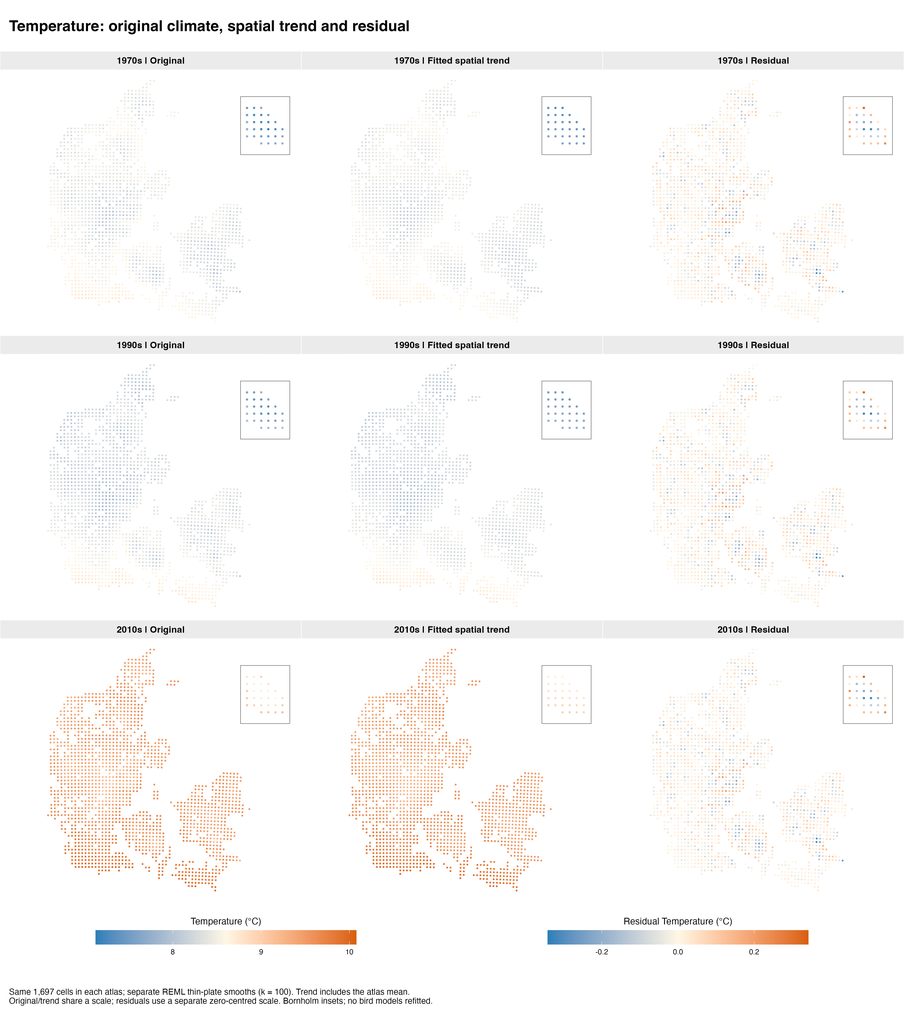

## Precipitation maps

The same display rules apply, now in mm/season. Different residual and original colour scales are necessary to see the residual patterns; compare their numeric legends and SDs rather than interpreting colour intensity as equal magnitude.

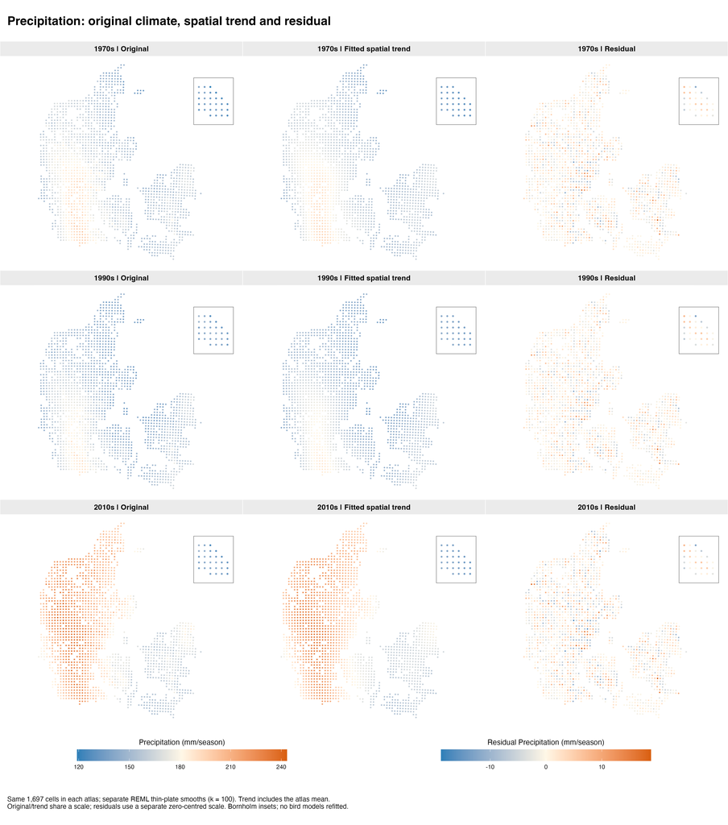

## Spatial autocorrelation before and after detrending

We use the same symmetrised four-nearest-neighbour graph for every field and atlas: an edge is present if either cell selects the other among its four nearest neighbours. Consequently, some cells have more than four neighbours. Weights are row-standardised. The graph has **5 connected components**; disconnected geographical groups are retained.

Moran’s I is reported as a descriptive measure of neighbouring similarity. Ordinary independent-cell correlation p-values and Moran significance tests are not calculated. Neighbourhood definition influences the statistic, so it should be read alongside the distance-based diagnostics below.

At k = 100, residual Moran’s I is **0.358–0.364** for temperature and **0.140–0.150** for precipitation. Detrending reduces spatial autocorrelation but does **not** eliminate it. These are residual climate fields, not independent observations.

### Temperature by distance

The upper row shows empirical semivariance in physical units. The middle row divides each semivariogram by that field’s own sample variance, making residual spatial structure visible despite its reduced magnitude. The bottom row shows unordered pair counts, identical across atlases and fields because we use the same cells. Bins are (0,10], (10,20], …, (190,200] km. This 200-km limit applies only to the displayed semivariograms; all cells inform the GAMs and the neighbour graph.

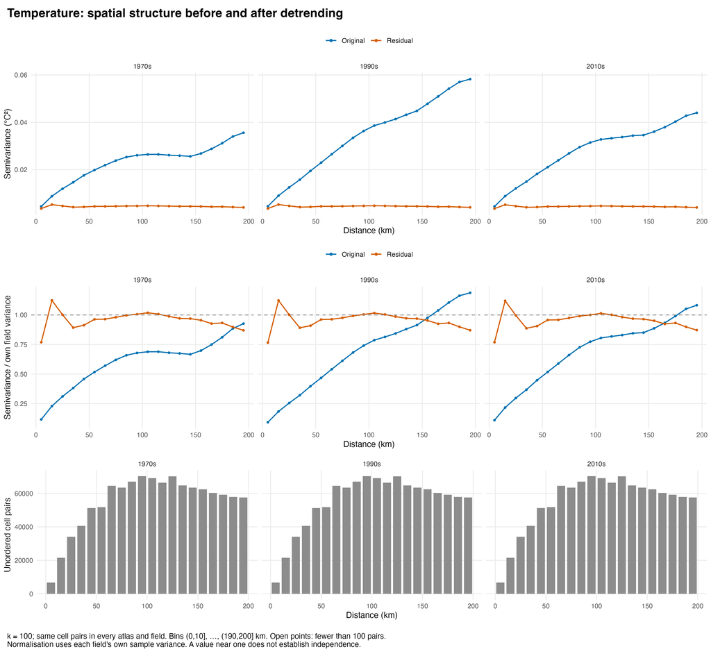

### Precipitation by distance

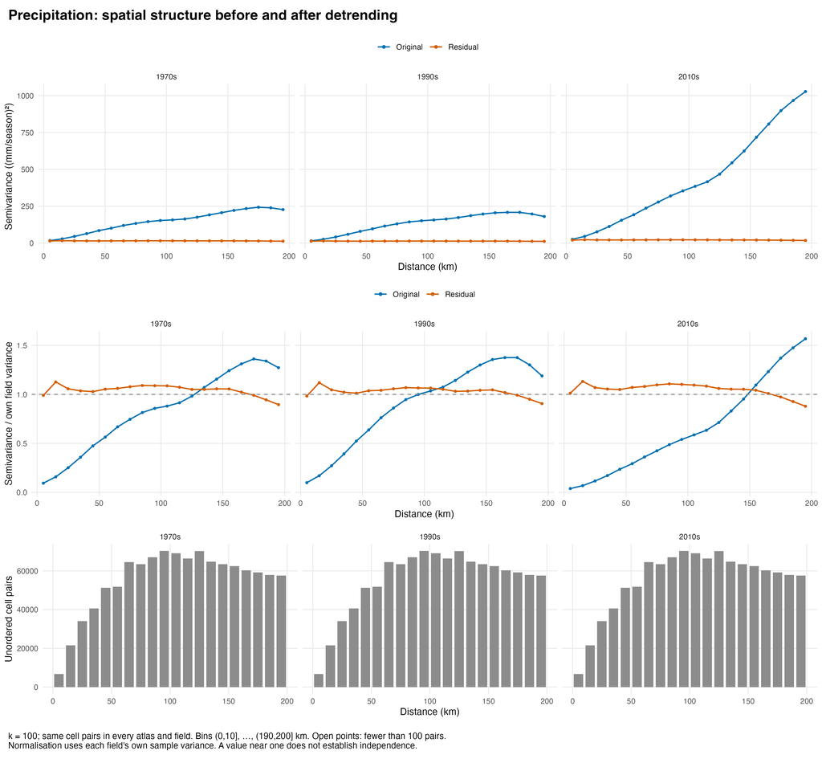

The dashed value of one means semivariance equals the corresponding field’s sample variance. It is a reference, not proof of independence or a justified cutoff for resampling. Open symbols flag bins with fewer than 100 pairs. No confidence intervals or automatic spatial-range estimates are assigned.

Cell pairs contributing to each displayed distance bin; shared across all six climate fields.

| Bin | Midpoint (km) | Unordered pairs |
| --- | --- | --- |
| 1 | 5 | 6751 |
| 2 | 15 | 21480 |
| 3 | 25 | 34009 |
| 4 | 35 | 40538 |
| 5 | 45 | 51243 |
| 6 | 55 | 51766 |
| 7 | 65 | 64480 |
| 8 | 75 | 63411 |
| 9 | 85 | 67013 |
| 10 | 95 | 70321 |
| 11 | 105 | 69126 |
| 12 | 115 | 66346 |
| 13 | 125 | 70209 |
| 14 | 135 | 64775 |
| 15 | 145 | 63478 |
| 16 | 155 | 62433 |
| 17 | 165 | 60272 |
| 18 | 175 | 59169 |
| 19 | 185 | 57867 |
| 20 | 195 | 57598 |

## Sensitivity to smoothing flexibility

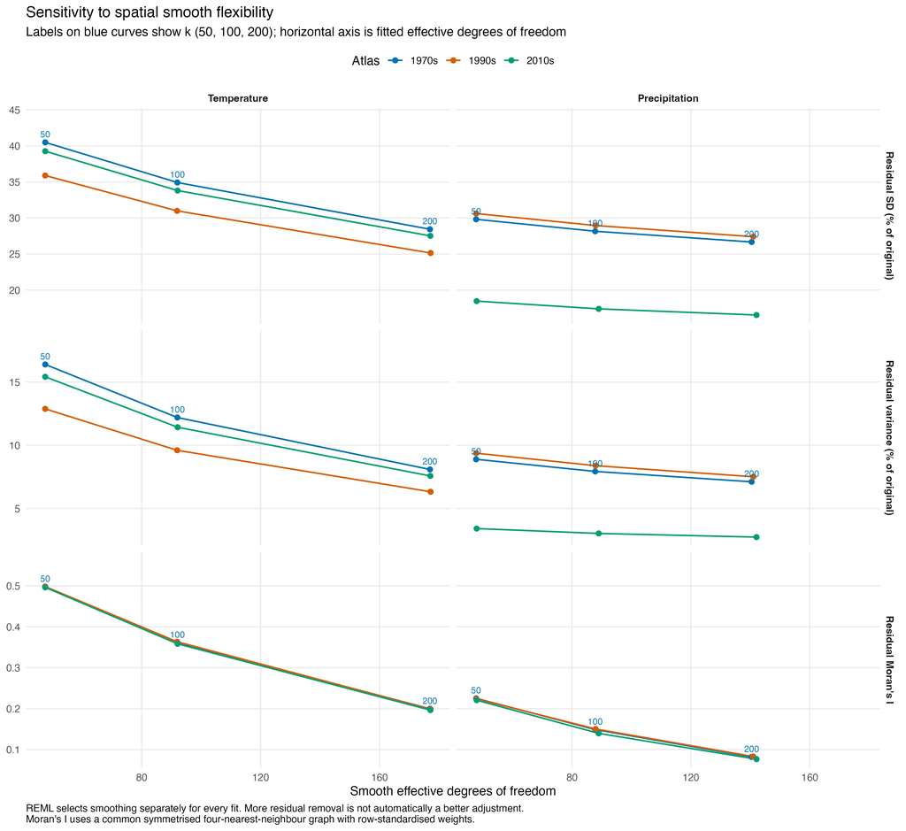

Labels on the blue curves indicate k for the three settings used by every atlas; horizontal positions indicate the smooth’s actual EDF. Each fit has its own REML-selected smoothing penalty. The sensitivity check asks how the amount and spatial structure of residual climate depend on that adjustment. It is not a competition to minimise Moran’s I or residual variance. Finer spatial adjustment can remove climate information needed for the intended species-response question.

Variation remaining and spatial autocorrelation for every basis setting.

| Climate | Atlas | k | Original SD | Residual SD | Variance retained (%) | EDF | Original Moran I | Residual Moran I |
| --- | --- | --- | --- | --- | --- | --- | --- | --- |
| Temperature | 1 | 50 | 0.196 | 0.079 | 16.4 | 47.5 | 0.910 | 0.498 |
| Temperature | 1 | 100 | 0.196 | 0.068 | 12.2 | 92.0 | 0.910 | 0.362 |
| Temperature | 1 | 200 | 0.196 | 0.056 | 8.1 | 177.0 | 0.910 | 0.200 |
| Temperature | 2 | 50 | 0.222 | 0.080 | 12.9 | 47.5 | 0.927 | 0.498 |
| Temperature | 2 | 100 | 0.222 | 0.069 | 9.6 | 91.9 | 0.927 | 0.364 |
| Temperature | 2 | 200 | 0.222 | 0.056 | 6.3 | 177.2 | 0.927 | 0.199 |
| Temperature | 3 | 50 | 0.202 | 0.079 | 15.4 | 47.5 | 0.913 | 0.496 |
| Temperature | 3 | 100 | 0.202 | 0.068 | 11.4 | 92.1 | 0.913 | 0.358 |
| Temperature | 3 | 200 | 0.202 | 0.056 | 7.6 | 177.1 | 0.913 | 0.197 |
| Precipitation | 1 | 50 | 13.359 | 3.984 | 8.9 | 47.7 | 0.922 | 0.225 |
| Precipitation | 1 | 100 | 13.359 | 3.763 | 7.9 | 87.8 | 0.922 | 0.149 |
| Precipitation | 1 | 200 | 13.359 | 3.563 | 7.1 | 140.4 | 0.922 | 0.082 |
| Precipitation | 2 | 50 | 12.308 | 3.769 | 9.4 | 47.8 | 0.918 | 0.224 |
| Precipitation | 2 | 100 | 12.308 | 3.564 | 8.4 | 88.0 | 0.918 | 0.150 |
| Precipitation | 2 | 200 | 12.308 | 3.374 | 7.5 | 141.0 | 0.918 | 0.083 |
| Precipitation | 3 | 50 | 25.609 | 4.731 | 3.4 | 47.9 | 0.968 | 0.221 |
| Precipitation | 3 | 100 | 25.609 | 4.456 | 3.0 | 89.0 | 0.968 | 0.140 |
| Precipitation | 3 | 200 | 25.609 | 4.238 | 2.7 | 142.1 | 0.968 | 0.077 |

### Basis and convergence diagnostics

All 18 GAMs must pass the optimiser convergence checks before the report can render. The k-index compares nearby residual differences with overall residual variation. Low values can indicate remaining spatial structure or inadequate basis flexibility; for these spatially correlated gridded climate fields they are exploratory diagnostics, not an independent-error test proving that a particular k is correct. EDF close to the basis maximum warrants particular attention. No basis-diagnostic p-values are used to select a final adjustment.

For the main k = 100 fits, smooth EDF ranges from **87.8 to 92.1**, out of a maximum of 99. Together with the changes at k = 200, this underlines that the main display is an exploratory adjustment, not a settled choice of spatial scale.

GAM convergence and basis diagnostics; no single adjustment is selected here.

| Climate | Atlas | k | EDF | EDF / maximum (%) | k-index | Converged |
| --- | --- | --- | --- | --- | --- | --- |
| Temperature | 1 | 50 | 47.5 | 97.0 | 0.471 | TRUE |
| Temperature | 1 | 100 | 92.0 | 92.9 | 0.598 | TRUE |
| Temperature | 1 | 200 | 177.0 | 88.9 | 0.762 | TRUE |
| Temperature | 2 | 50 | 47.5 | 97.0 | 0.470 | TRUE |
| Temperature | 2 | 100 | 91.9 | 92.8 | 0.595 | TRUE |
| Temperature | 2 | 200 | 177.2 | 89.0 | 0.762 | TRUE |
| Temperature | 3 | 50 | 47.5 | 97.0 | 0.472 | TRUE |
| Temperature | 3 | 100 | 92.1 | 93.0 | 0.601 | TRUE |
| Temperature | 3 | 200 | 177.1 | 89.0 | 0.765 | TRUE |
| Precipitation | 1 | 50 | 47.7 | 97.4 | 0.748 | TRUE |
| Precipitation | 1 | 100 | 87.8 | 88.7 | 0.823 | TRUE |
| Precipitation | 1 | 200 | 140.4 | 70.6 | 0.892 | TRUE |
| Precipitation | 2 | 50 | 47.8 | 97.5 | 0.747 | TRUE |
| Precipitation | 2 | 100 | 88.0 | 88.8 | 0.820 | TRUE |
| Precipitation | 2 | 200 | 141.0 | 70.8 | 0.890 | TRUE |
| Precipitation | 3 | 50 | 47.9 | 97.8 | 0.751 | TRUE |
| Precipitation | 3 | 100 | 89.0 | 89.9 | 0.831 | TRUE |
| Precipitation | 3 | 200 | 142.1 | 71.4 | 0.896 | TRUE |

## Implications for changing species–climate responses

This check shows what climate contrasts remain after removing a specified smooth spatial trend. It does not establish whether those remaining contrasts are sufficient to estimate species responses: that depends on bird occurrence, other predictors, sample support, and the outcome model.

In particular, each separate atlas fit subtracts its own intercept and smooth. It removes the atlas’s average climate level as well as broad spatial gradients. The resulting residuals therefore do **not** retain all information about warming, precipitation change, or broad-scale species–climate relationships. A residual-based analysis asks about departures from the fitted geographical trend. Extrapolating its coefficient to the original broad climate gradient requires additional assumptions.

This is only a first-stage exploration motivated by [Spatial+](https://onlinelibrary.wiley.com/doi/full/10.1111/biom.13656). It does not replicate or validate a complete Spatial+ model for the multivariate Hmsc analysis. Uncertainty in the fitted climate trend is not propagated here; no first-stage or bird-model credible intervals are produced. Residual climate is not guaranteed orthogonal to every possible spatial effect, and adjustment of temperature and precipitation separately does not remove their mutual correlation or confounding by other covariates.

A future outcome-model comparison would need to specify the spatial adjustment consistently, inspect remaining climate support, propagate relevant uncertainty, and test recovery of known constant and changing responses. We have not chosen a final k, modified the environmental inputs, or refitted any bird models.

## Reproducibility and validation

Knit this document to rerun all 18 fits, regenerate the five PNGs, and embed them in a self-contained HTML report. From the repository root:

```r
rmarkdown::render('scripts/5-vis/spatial-latents/climate-spatial-residualisation.Rmd')
```

The adjacent R script retains fitted GAMs, decomposition values, summaries, common-cell IDs, spatial graph, semivariograms, and pair counts in memory. It checks input alignment, identical coordinates across atlases, the 1,697-cell intersection, finite values, optimiser convergence, approximately zero residual means, and exact reconstruction of original climate as fitted trend plus residual. Selected pair distances are independently checked against coordinate differences; spatial weights and distance bins are reused across all fields. All source inputs and fitted bird models are read only. Plots are PNG only.